# An Agent-based model to simulate the transmission of SARS-CoV-2 in meat processing facilities

**SACADA Project**

*April 2021 - September 2022*

# **Introduction**

In order to consider the first source of contamination (in the factory), the durations of the stages of infections and the Viral load (viral RNA concentration) exhaled by infected people have to be quantified. For assessing the possibility of transmission in community the secondary attack rate have to be quantified.

The different waves of Sars-CoV2 outbreaks that have occurred show that each Variants of Concern, i.e. VoC (alpha, beta, delta and omicron SARS-CoV-2 VoCs) have their own characteistics, e.g. different viral load, or rates of reinfection (Karim & Karim, 2021).

This document aims to identify the parameters of interest for building the Agent Based Model of the ANR Sacada project.

# **Agent-based modeling**

The ABM model is presented in this study according to the Overview-Design-Details (ODD) protocol as recommended by Grimm et al. (2010).

## **Overview**

The outline of the agent-based modelling workflow developed in this study is schematized in Figure 1.

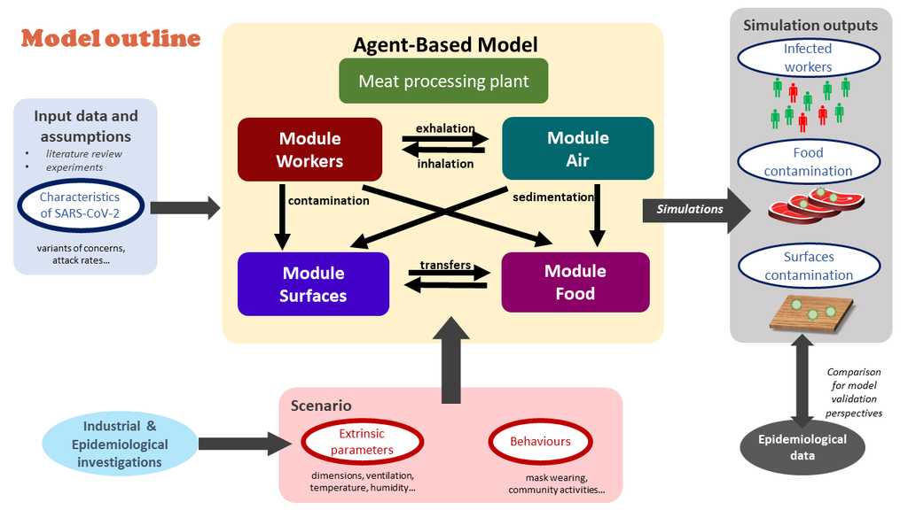

Figure 1: Outline of the Agent-based model to simulate the transmission of SARS-CoV-2 in meat processing facilities

**Purpose and patterns**

**States variables and scales - Parameters overview**

**Process overview and scheduling**

The model was divided in four separate modules describing different agents evolving in the processing plant including (i) the workers, (ii) the droplets in the air, (iii) the inert surfaces and (iv) the food products, respectively. As schematized in Figure 1, different possible interactions between these agents were described, such as the transmission of the droplets probably containing viral particles between infectious workers and the air through their respiratory activities (exhalation and inhalation), the sedimentation of these droplets from the air onto inert surfaces and/or food portions as well as the transfers between surfaces and food, etc. Based on prior data or knowledge, spatiotemporal rules were defined to simulate the interactions between modules and the properties of every agents at successive time points distanced by a predefined short time step (minutes). These step-by-step simulations were performed afterwards for longer periods (days, weeks, etc.). At the end of these periods, balances were calculated for different properties of the agents, e.g. the total number of aerosolized or fallen droplets, the number of viral gene copies inhaled by each worker, etc. Based on these balances, several contamination indicators were estimated such as the total number of infected workers, the number of contaminated food portions and surfaces in the plant, etc. These estimated indicators could be compared with collected epidemiological data for further model validation purposes.

## **Design concept**

**Basic principles**

The different agents integrated into the model for describing the functioning of the meat processing plant are illustrated in Figure 2. The model was implemented in the way that end-users can include by themselves as input data the different characteristics of the plant such as its dimensions, structures, objects, etc. For instance, as shown in Figure 2, the illustrated plant is made up of several rooms / spaces including an entry hall for workers, an office, a cooling area for food storage, a large area for meat cutting activities with two conveyor belts for food transfers and a packaging machine, etc. Different types of workers were considered in the model depending on their respective activities, including the cutters, the logistic workers as well as the ones with transverse activities. The number of workers of each type present in the plant and their respective working rhythm and timetable condition then the daily meat processing flow (meat quantity, processing duration) of the overall plant. This processing flow was described as successive transformation steps of the meat products: the carcasses/half-carcasses arriving in the plant through the gate are transported to the conveyors by logistic workers, become smaller meat portions after different cutting steps carried out by cutters around the conveyors and eventually packed and stored in the cooling area. Other workers with transverse activities such as manager, administrative or cleaning workers can also be present in the plant at different moments depending on their respective timetable. Based on the overall timetable of the plant, one can define rules for generating predefined or random movements of every agents (workers, carcasses, meat cuts…) between different locations in the plant at different time points. Determining these movements over time will allow then to track the possible transmission of the virus introduced by one or several infectious workers in the plant.

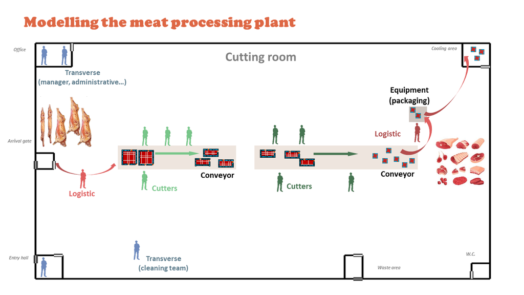

Figure 2: Illustration : Modeling the meat processing plant

The transmission of the virus from one or several infectious workers to other susceptible workers, surfaces and food products are schematized in the Figure 3. In this study, the duration between the different successive infection phases were taken into account from new infection to recovery with/without symptoms development. The different infectious workers can exhale into the air, through their respiratory activities or symptoms such as breathing, talking, sneezing or coughing, different amounts of droplets containing or not viral particles due to variability between workers and depending on their behavior (mask wearing). These droplets of various sizes can be aerosolized and/or fall afterwards onto inert surfaces and food products depending on the characteristics of the ventilation system in each space of the plant. Some high-diameter droplets sent out by the infectious workers (e.g. in cases of sneezing or coughing) can also fall directly onto surfaces without being aerosolized and/or projected towards nearby workers. The total viral loads on different surfaces and/or food products (meat cuts) are also enumerated; they are considered as contaminated if the viral loads exceed a predefined threshold value. The non-infected workers (susceptible workers) can inhale more or less of droplets depending on their positions in the plant at different moments. The cumulative viral doses inhaled by each susceptible worker at the end of the day can then probably trigger an infection following a dose-response relationship. At last, in addition of these possible infections inside the plant, the model included also other contamination sources outside the plant: the susceptible workers can get infected due to the outside epidemic situation and or by community activities such as co-living with infectious workers.

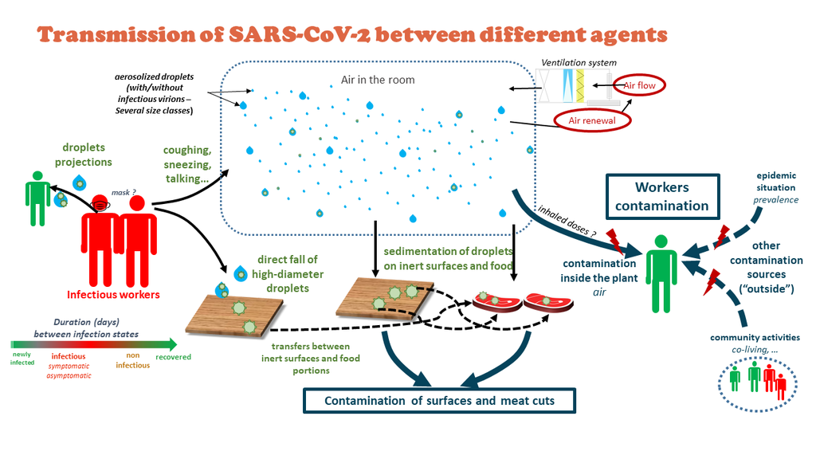

Figure 3: Modeling the transmission of SARS-CoV-2 between different agents

**Prediction**

**Stochasticity**

## **Details**

### **Sub-models**

#### **Food processing plant**

**Dimensions and structures**

The plan of the multi-room food processing plant can be taken into account in the model. Based on industrial investigations, seven principal rooms (spaces) were included herein as an example to define the plant structure, including the Cutting room (the main space of the plant), Entry hall (for workers), Arrival gate (for food arrival into the cutting room), Cooling area (for food storage), Waste area, W.C., and Office (illustration in Figure 2).

The different characteristics of each room are included as inputs of the model :

- dimensions of the plant and dimensions of the different rooms, expressed in *m* (the length and width on two axes, denoted X and Y axes, respectively, and height on a 3rd axis, denoted Z axis);
- positions of the room in the plant;
- presence and relative positions of internal/external door for each room;
- ventilation specifications: several air conditioning types can be indicated such as Controlled Mechanical Ventilation (CMV), Direct Expansion Coil (DEC) or Air Handing Unit (AHU).

The above characteristics were defined in the model as model parameters based on industrial investigations or previous works. For example, each room needs to be positioned on the entire workshop grid using a numerical value between 0 and 1 indicating the relative position over the axes. The cutting room is the main build by subtracting all other rooms. The position of the internal and external doors can also be mentioned using the predefined values “top”, “bottom”, “left” or “right”.

**Equipment and objects**

The different objects or equipment can be included inside the plant such as conveyors, peeler, etc. In the same ways as for the different rooms, their dimensions and their relative position alongside the X and Y axes are taken into account as model inputs. As illustrated in Figure 2, two types of objects were included : two conveyors allowing to transport the different carcasses or food portions from one point to another, and an equipment that can be shared by several operators (e.g.: a peeler, frequently used in meat cutting plant).

Table 1: Set of parameters for charateryzing the different objects in the plant.

| Parameters | name of the object | length of the object | width of the object | Position of regarding the X axis of the plant | Position regarding the Y axis of the plant |
| --- | --- | --- | --- | --- | --- |
| Label in ABM script | label | dim.X | dim.Y | pos.X | pos.Y |
| unit |  | meter | meter | 0 to 1 (0: left, 0.5: middle, 1:right) | 0 to 1 (0: bottom, 0.5: middle, 1:top) |
| cvy | Conveyor1 | 13 | 3 | 0.2 | 0.5 |
| cvy2 | Conveyor2 | 18 | 3 | 0.5 | 0.5 |
| epmA | Equipment 1 | 2 | 2 | 0.85 | 0.7 |

#### **Workers**

##### Characteristics

Different principal types of workers were taken into account in the model depending on the their daily tasks inside the plant. According to industrial investigations and expert knowledge, six types of workers were included as following (Figure 2):

- *logistic1* : the workers in charge of bringing carcasses (or half-carcasses), arriving in the cutting room through the arrival gate, to the begin of the conveyor for cutting.
- *cutter1* : positioned around the first section of the conveyor, denoted *conveyor1*, in charge of deboning, trimming and cutting carcasses into large pieces;
- *cutter2* : workers in charge of cutting larges pieces from *cutter1* into smaller food portions;
- *logistic2* : the workers in charge of transferring food portions from the cutting tables to the packaging or supplementary treatment equipment and storing packed products in the cooling area;
- *transverse1*: administrative workers such as manager, chief or maintenance staff who mainly stay out of the cutting room during the work day;
- *transverse2*: people from the cleaning team.

The total number of employees is defined as shown is Table 2.

Table 2: Set of parameters used for charateryzing the worker of the plant.

| Parameters | Label in ABM script | Value | Unit | Uncertainty range | References |
| --- | --- | --- | --- | --- | --- |
| Total number of worker | Nworkers | 100.000 | N/A | [??-??] | [interviews] |
| Number of regular worker | Nworkers_ext | 15.000 | N/A | [1-4] | [interviews] |
| Number of temporary worker |  | NA |  |  |  |
| Number of subcontract worker |  | NA |  |  |  |
| *Overall proportion for different types of workers* |  |  |  |  |  |
| Cutter | cutter1 | 0.360 | ratio (0 to 1) | [5-11] | (Mallet et al., 2021) |
| Cutter | cutter2 | 0.470 | ratio (0 to 1) | [5-11] | (Mallet et al., 2021) |
| Logistic | logistic1 | 0.040 | ratio (0 to 1) |  | (Gunther et al., 2020) |
| Logistic | logistic2 | 0.040 | ratio (0 to 1) |  | (Gunther et al., 2020) |
| Transverse | transverse1 | 0.045 | ratio (0 to 1) | [0.18-0.475] | (Mallet et al., 2021) |
| Transverse | transverse2 | 0.045 | ratio (0 to 1) |  | (Mallet et al., 2021) |

The workers were split afterwards into two teams, denoted *“team A”* and *“team B”* according to their working shift (morning or afternoon) and to their weekly schedule. In the model, this team dividing was included by the parameters *pTeam* (value between 0 and 1 representing the proportion of each team) and set by default at 0.5 (equal distribution between the two teams A and B). In each team, the types of workers (cutters, transverse and logistic workers) were proportionally distributed as described above. The two teams A and B alternatively change their shift (morning/afternoon) from one week to another. Finally, the workers change the team (between the teams A and B) from one week to another using a probability defined as model parameter, denoted *pChangeTeam*, (value between 0 and 1), arbitrarily set as 0.05.

##### Rules

#### **Air**

##### Circulation of the droplets

##### Processing rules

#### **Workers contamination**

##### *Infection phases*

The parameters associated with the duration of different infections phases were considered as fixed. These phases are schematized in Figure 4). The uncertainty ranges of the different values have been identified for sensitivity analysis of the hypothesis of the model (Table 3).

For the symptomatic population, the mean duration of symptoms has been found uncertain according to studies (Byrne et al., 2020). The durations of the differents symptoms differ according to their nature (Santos et al., 2021). From the onset of symptoms to recovery, a period of 13 days can be considered With an uncertainty range comprise between 11 and 16 days (Byrne et al., 2020). During that period, virus can be detected but it as estimated that infectiousness is usually low after 7 days (X. He et al., 2020). The uncertainty range for the infectiousness period can be estimated from Byrne et al. (2020). They stated that virus detection overestimates the infectious period on average by 2-6 days. Kampen et al. (2021) provide another estimation of the uncertainty range of infectiousness period. They considered the duration between 5 and 11 days. The value of 8 days (Kampen et al., 2021) was used in the model .

[interactive chart not shown]

Figure 4: Representation of the stage of infection for SARS-CoV2

Table 3: Set of parameters used for charateryzing the durations of the SARS-CoV2 infection.

| Parameters | Label in ABM script | Value | Unit | Uncertainty range | References |
| --- | --- | --- | --- | --- | --- |
| Latent phase of presymptomatic period | InfectiousBeginDay | 3 | days | [0-8] | (Zhao et al., 2021) |
| Infectious phase of presymtomatic period | xx | 2 | days | [1-4] | (Byrne et al., 2020) |
| Duration of the presymtomatic period | PossibleSymptomeBeginDay | InfectiousBeginDay+XX | days |  |  |
| Infectious phase after presymptomatic period for symptomatic people | yy | 8 | days | [5-11] | (Byrne et al., 2020; Kampen et al., 2021) |
| Infectious phase after presymptomatic period for asymptomatic people | zz | 8 | days | [5-11] | (Byrne et al., 2020) |
| End of the infectious period for symtomactic | NonInfectiousBeginDay | PossibleSymptomBegin+yy | days |  |  |
| End of the infectious period for asymtomactic | NonInfectiousBeginDayAS (Du) | PossibleSymptomBegin+zz | days |  |  |
| Proportion of asymptomatic |  | 0.335 |  | [0.18-0.475] | (Alene et al., 2021; Ma et al., 2021; Sah et al., 2021) |

##### *Individual variability in viral load*

In the ABM, viral load was modeled only during the period of infectiousness of individuals. Viral loads were considered to be similar between asymptomatic and symptomatic persons (Walsh et al., 2020). During the infectiousness period, the viral load for an individual was considered to be constant. The Agent-Based model takes into account the between individual variability of virus load in sputum and the VoC.

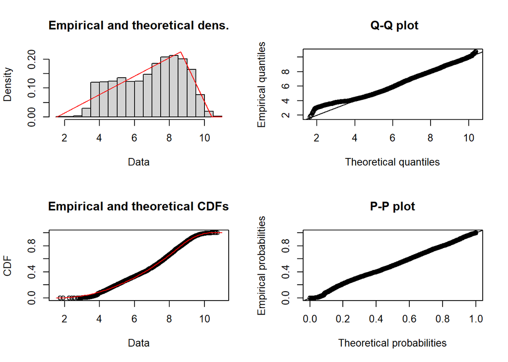

Figure 5: Fitting of triangular distribution to virus load measurements in log10 (copy/ml). Data from Jones et al (2021)

The parameters of the triangular distribution used to describe variability of viral load are respectively, min=1.6, mode=8.6 and max=10.4.

The delta VoC is associated with higher viral load (Luo et al., 2021; Teyssou et al., 2021; Wang et al., 2021). The concentration of delta VoC was found to be 2 times more important than for delta (Teyssou et al., 2021). Other differences observed in Ct values suggest that the difference could be higher (Luo et al., 2021; Wang et al., 2021). In the ABM model the distribution of viral load was considered to be shifted by 0.5 log10 for delta variant with an uncertainty range between 0.3 and 1 log10.

The level of viral load for omicron VoC was found to be similar to delta virus load (Lyngse et al., 2021).

Table 4: Set of parameters used for triangular distribution used for charateryzing variability of VoC viral loads in log10 (copy/ml) in stupum.

| VoC | Min | Mode | Max | Shift compared to delta | Reference |
| --- | --- | --- | --- | --- | --- |
| delta | 1.6 | 8.6 | 10.4 | NA | (Jones et al., 2021) |
| original | 0.6 | 7.6 | 9.4 | -1.0 | (Teyssou et al., 2021) |
| alpha | 1.1 | 8.1 | 9.9 | -0.5 | (Luo et al., 2021; Teyssou et al., 2021; Wang et al., 2021) |
| omicron | 1.6 | 8.6 | 10.4 | 0.0 | (Lyngse et al., 2021) |

##### *Secondary attack rate*

Table 5: Set of parameters used for secondary attack rate in household according to VoC and vaccination status.

| VoC | Unvaccinated | X95 CI range | Vaccinated | X95 CI range 1 | Multiplication factor toward a reference | Reference |
| --- | --- | --- | --- | --- | --- | --- |
| original | 17% | [14%-21%] |  |  |  | (Fung et al., 2021) |
| alpha | 17% | [14%-21%] |  |  |  | (Fung et al., 2021) |
| delta | 38% | [24%-53%] | 25% | [18%-33%] |  | (Singanayagam et al., 2021) |
| omicron | 57% |  | 37.5% |  | 1.5 more than delta | (Lyngse et al., 2021) |

##### *Dose-response modelling*

Principles of the dose-response modelling approaches

#### **Surfaces**

#### **Food**

##### Characteristics

- The type of meat
- Ncarcass_daily
- carcass_weight
- net_weight
- CSU

##### Rules

- All characteristics of the agents “food portions” were initialized daily. The food portions came from different carcasses. The total number of carcasses (and agents) was calculated each day depending on the expected total meat quantity produced by the establishment (expressed as number of carcasses per day or per week). Each initialized agent had a unique ID (e.g: B_12_028_004 corresponds to the 4th portion of the 28th carcass of the 12th day, “B” stands for “bovine”).
- The duration (expressed in minutes) corresponding to different cutting steps for each carcass and for separating food portions at different locations in the plant were estimated/assumed based on information from industrial interviews. Hence, knowing this duration, the carcasses could arrive sequentially and/or simultaneously in the cutting room depending on the expected number of carcasses per day.

### **Input data - Reference scenario**

Scenario chosen based on an epidemiological investigation on several SARS-CoV-2 clusters in France during the period between May 2020 and April 2021.

For each simulation, the model was initialized at the first day with an initial number of infected workers $n_{Contaminated-Init} = 5$

### **Parallel computing**

R package parallel

### **Convergence check**

### **Uncertainty analyses**

### **Model validation**

Alene, M., Yismaw, L., Assemie, M. A., Ketema, D. B., Mengist, B., Kassie, B., & Birhan, T. Y. (2021). Magnitude of asymptomatic COVID-19 cases throughout the course of infection: A systematic review and meta-analysis. *PloS One*, *16*(3), e0249090.

Byrne, A. W., McEvoy, D., Collins, A. B., Hunt, K., Casey, M., Barber, A., et al.others. (2020). Inferred duration of infectious period of SARS-CoV-2: Rapid scoping review and analysis of available evidence for asymptomatic and symptomatic COVID-19 cases. *BMJ Open*, *10*(8), e039856.

Fung, H. F., Martinez, L., Alarid-Escudero, F., Salomon, J. A., Studdert, D. M., Andrews, J. R., … Modeling Group Chin Elizabeth T Claypool Anneke L Fernandez Mariana Gracia Valeria Luviano Andrea Rosales Regina Isabel Medina Reitsma Marissa Ryckman Theresa, S.-C. C. S. M. (SC-COSMO). (2021). The household secondary attack rate of severe acute respiratory syndrome coronavirus 2 (SARS-CoV-2): A rapid review. *Clinical Infectious Diseases*, *73*(Supplement_2), S138–S145.

Grant, R., Charmet, T., Schaeffer, L., Galmiche, S., Madec, Y., Von Platen, C., … Fontanet, A. (2021). Impact of SARS-CoV-2 delta variant on incubation, transmission settings and vaccine effectiveness: Results from a nationwide case-control study in france. *The Lancet Regional Health - Europe*, 100278. doi:10.1016/j.lanepe.2021.100278

Grimm, V., Berger, U., DeAngelis, D. L., Polhill, J. G., Giske, J., & Railsback, S. F. (2010). The ODD protocol: A review and first update. *Ecological Modelling*, *221*(23), 2760–2768. doi:10.1016/j.ecolmodel.2010.08.019

Gunther, T., Czech-Sioli, M., Indenbirken, D., Robitaille, A., Tenhaken, P., Exner, M., … Brinkmann, M. M. (2020). SARS-CoV-2 outbreak investigation in a german meat processing plant. *EMBO Mol Med*, *12*(12), e13296. Journal Article. doi:10.15252/emmm.202013296

He, J., Guo, Y., Mao, R., & Zhang, J. (2021). Proportion of asymptomatic coronavirus disease 2019: A systematic review and meta-analysis. *Journal of Medical Virology*, *93*(2), 820–830.

He, X., Lau, E. H., Wu, P., Deng, X., Wang, J., Hao, X., et al.others. (2020). Temporal dynamics in viral shedding and transmissibility of COVID-19. *Nature Medicine*, *26*(5), 672–675.

Jones, T. C., Biele, G., Mühlemann, B., Veith, T., Schneider, J., Beheim-Schwarzbach, J., et al.others. (2021). Estimating infectiousness throughout SARS-CoV-2 infection course. *Science*.

Kampen, J. J. van, Vijver, D. A. van de, Fraaij, P. L., Haagmans, B. L., Lamers, M. M., Okba, N., et al.others. (2021). Duration and key determinants of infectious virus shedding in hospitalized patients with coronavirus disease-2019 (COVID-19). *Nature Communications*, *12*(1), 1–6.

Kang, M., Xin, H., Yuan, J., Ali, S. T., Liang, Z., Zhang, J., et al.others. (2021). Transmission dynamics and epidemiological characteristics of delta variant infections in china. *Medrxiv*.

Karim, S. S. A., & Karim, Q. A. (2021). Omicron SARS-CoV-2 variant: A new chapter in the COVID-19 pandemic. *The Lancet*, *398*(10317), 2126–2128.

Lau, E. H., & Leung, G. M. (2020). Reply to: Is presymptomatic spread a major contributor to COVID-19 transmission? *Nature Medicine*, *26*(10), 1534–1535.

Luo, C. H., Morris, C. P., Sachithanandham, J., Amadi, A., Gaston, D., Li, M., et al.others. (2021). Infection with the SARS-CoV-2 delta variant is associated with higher infectious virus loads compared to the alpha variant in both unvaccinated and vaccinated individuals. *medRxiv*.

Lyngse, F. P., Mortensen, L. H., Denwood, M. J., Christiansen, L. E., Møller, C. H., Skov, R. L., et al.others. (2021). SARS-CoV-2 omicron VOC transmission in danish households. *medRxiv*.

Ma, Q., Liu, J., Liu, Q., Kang, L., Liu, R., Jing, W., … Liu, M. (2021). Global percentage of asymptomatic SARS-CoV-2 infections among the tested population and individuals with confirmed COVID-19 diagnosis: A systematic review and meta-analysis. *JAMA Network Open*, *4*(12), e2137257–e2137257.

Mallet, Y., Pivette, M., Revest, M., Angot, E., Valence, M., Dupin, C., … Guillois, Y. (2021). Identification of workers at increased risk of infection during a COVID-19 outbreak in a meat processing plant, france, may 2020. *Food and Environmental Virology*, 1–9. Journal Article. doi:10.1007/s12560-021-09500-1

Sah, P., Fitzpatrick, M. C., Zimmer, C. F., Abdollahi, E., Juden-Kelly, L., Moghadas, S. M., … Galvani, A. P. (2021). Asymptomatic SARS-CoV-2 infection: A systematic review and meta-analysis. *Proceedings of the National Academy of Sciences*, *118*(34).

Santos, R. E. A., Silva, M. G. da, Monte Silva, M. C. B. do, Barbosa, D. A. M., Vale Gomes, A. L. do, Galindo, L. C. M., … Ferraz-Pereira, K. N. (2021). Onset and duration of symptoms of loss of smell/taste in patients with COVID-19: A systematic review. *American Journal of Otolaryngology*, 102889.

Singanayagam, A., Hakki, S., Dunning, J., Madon, K. J., Crone, M. A., Koycheva, A., et al.others. (2021). Community transmission and viral load kinetics of the SARS-CoV-2 delta (b. 1.617. 2) variant in vaccinated and unvaccinated individuals in the UK: A prospective, longitudinal, cohort study. *The Lancet Infectious Diseases*.

Teyssou, E., Delagrèverie, H., Visseaux, B., Lambert-Niclot, S., Brichler, S., Ferre, V., et al.others. (2021). The delta SARS-CoV-2 variant has a higher viral load than the beta and the historical variants in nasopharyngeal samples from newly diagnosed COVID-19 patients. *Journal of Infection*, *83*(4), e1–e3.

Walsh, K. A., Jordan, K., Clyne, B., Rohde, D., Drummond, L., Byrne, P., … Harrington, P. (2020). SARS-CoV-2 detection, viral load and infectivity over the course of an infection. *Journal of Infection*, *81*(3), 357–371. doi:10.1016/j.jinf.2020.06.067

Wang, Y., Chen, R., Hu, F., Lan, Y., Yang, Z., Zhan, C., et al.others. (2021). Transmission, viral kinetics and clinical characteristics of the emergent SARS-CoV-2 delta VOC in guangzhou, china. *EClinicalMedicine*, *40*, 101129.

Zhao, S., Tang, B., Musa, S. S., Ma, S., Zhang, J., Zeng, M., et al.others. (2021). Estimating the generation interval and inferring the latent period of COVID-19 from the contact tracing data. *Epidemics*, *36*, 100482.